# wineAnalysis

Ahmed Makkawi

February 7, 2019

# White Wine Analysis by Ahmed M.

P. Cortez, A. Cerdeira, F. Almeida, T. Matos and J. Reis. Modeling wine preferences by data mining from physicochemical properties. In Decision Support Systems, Elsevier, 47(4):547-553. ISSN: 0167-9236.

# Introduction

In the above reference, a dataset was created from white wine samples. The number of samples in this dataset is 4898 and its a tidy dataset. The output is generated based on a sensory data (median of at least 3 evaluations made by wine experts). Each expert graded the wine quality between 0 (very bad) and 10 (very excellent).

The specifications of each wine is specified with the below values: 1 - fixed acidity: most acids involved with wine or fixed or nonvolatile (do not evaporate readily)

2 - volatile acidity: the amount of acetic acid in wine, which at too high of levels can lead to an unpleasant, vinegar taste

3 - citric acid: found in small quantities, citric acid can add ‘freshness’ and flavor to wines

4 - residual sugar: the amount of sugar remaining after fermentation stops, it’s rare to find wines with less than 1 gram/liter and wines with greater than 45 grams/liter are considered sweet

5 - chlorides: the amount of salt in the wine

6 - free sulfur dioxide: the free form of SO2 exists in equilibrium between molecular SO2 (as a dissolved gas) and bisulfite ion; it prevents microbial growth and the oxidation of wine

7 - total sulfur dioxide: amount of free and bound forms of S02; in low concentrations, SO2 is mostly undetectable in wine, but at free SO2 concentrations over 50 ppm, SO2 becomes evident in the nose and taste of wine

8 - density: the density of water is close to that of water depending on the percent alcohol and sugar content

9 - pH: describes how acidic or basic a wine is on a scale from 0 (very acidic)to 14 (very basic); most wines are between 3-4 on the pH scale

10 - sulphates: a wine additive which can contribute to sulfur dioxide gas (S02) levels, wich acts as an antimicrobial and antioxidant

11 - alcohol: the percent alcohol content of the wine

Output variable (based on sensory data): 12 - quality (score between 0 and 10)

# Univariate Plots Section

```
## 'data.frame':    4898 obs. of  13 variables:
##  $ X                   : int  1 2 3 4 5 6 7 8 9 10 ...
##  $ fixed.acidity       : num  7 6.3 8.1 7.2 7.2 8.1 6.2 7 6.3 8.1 ...
##  $ volatile.acidity    : num  0.27 0.3 0.28 0.23 0.23 0.28 0.32 0.27 0.3 0.22 ...
##  $ citric.acid         : num  0.36 0.34 0.4 0.32 0.32 0.4 0.16 0.36 0.34 0.43 ...
##  $ residual.sugar      : num  20.7 1.6 6.9 8.5 8.5 6.9 7 20.7 1.6 1.5 ...
##  $ chlorides           : num  0.045 0.049 0.05 0.058 0.058 0.05 0.045 0.045 0.049 0.044 ...
##  $ free.sulfur.dioxide : num  45 14 30 47 47 30 30 45 14 28 ...
##  $ total.sulfur.dioxide: num  170 132 97 186 186 97 136 170 132 129 ...
##  $ density             : num  1.001 0.994 0.995 0.996 0.996 ...
##  $ pH                  : num  3 3.3 3.26 3.19 3.19 3.26 3.18 3 3.3 3.22 ...
##  $ sulphates           : num  0.45 0.49 0.44 0.4 0.4 0.44 0.47 0.45 0.49 0.45 ...
##  $ alcohol             : num  8.8 9.5 10.1 9.9 9.9 10.1 9.6 8.8 9.5 11 ...
##  $ quality             : int  6 6 6 6 6 6 6 6 6 6 ...
```

Dataset doesnt have any missing value

```
##        X        fixed.acidity    volatile.acidity  citric.acid
##  Min.   :   1   Min.   : 3.800   Min.   :0.0800   Min.   :0.0000
##  1st Qu.:1225   1st Qu.: 6.300   1st Qu.:0.2100   1st Qu.:0.2700
##  Median :2450   Median : 6.800   Median :0.2600   Median :0.3200
##  Mean   :2450   Mean   : 6.855   Mean   :0.2782   Mean   :0.3342
##  3rd Qu.:3674   3rd Qu.: 7.300   3rd Qu.:0.3200   3rd Qu.:0.3900
##  Max.   :4898   Max.   :14.200   Max.   :1.1000   Max.   :1.6600
##  residual.sugar     chlorides       free.sulfur.dioxide
##  Min.   : 0.600   Min.   :0.00900   Min.   :  2.00
##  1st Qu.: 1.700   1st Qu.:0.03600   1st Qu.: 23.00
##  Median : 5.200   Median :0.04300   Median : 34.00
##  Mean   : 6.391   Mean   :0.04577   Mean   : 35.31
##  3rd Qu.: 9.900   3rd Qu.:0.05000   3rd Qu.: 46.00
##  Max.   :65.800   Max.   :0.34600   Max.   :289.00
##  total.sulfur.dioxide    density             pH          sulphates
##  Min.   :  9.0        Min.   :0.9871   Min.   :2.720   Min.   :0.2200
##  1st Qu.:108.0        1st Qu.:0.9917   1st Qu.:3.090   1st Qu.:0.4100
##  Median :134.0        Median :0.9937   Median :3.180   Median :0.4700
##  Mean   :138.4        Mean   :0.9940   Mean   :3.188   Mean   :0.4898
##  3rd Qu.:167.0        3rd Qu.:0.9961   3rd Qu.:3.280   3rd Qu.:0.5500
##  Max.   :440.0        Max.   :1.0390   Max.   :3.820   Max.   :1.0800
##     alcohol         quality
##  Min.   : 8.00   Min.   :3.000
##  1st Qu.: 9.50   1st Qu.:5.000
##  Median :10.40   Median :6.000
##  Mean   :10.51   Mean   :5.878
##  3rd Qu.:11.40   3rd Qu.:6.000
##  Max.   :14.20   Max.   :9.000
```

above shows the ranges of each variable, it also shows that variable X is actually the same as the index, so we can drop it as it will not help in out investigation. It also shows that the quality of the wine is in range of 3 to 9.

column was made to be a qualitative value for the quality, where: 0 < Quality <= 5 -Bad 5 < Quality <= 7 -Ok 7 < Quality <= 10-Good

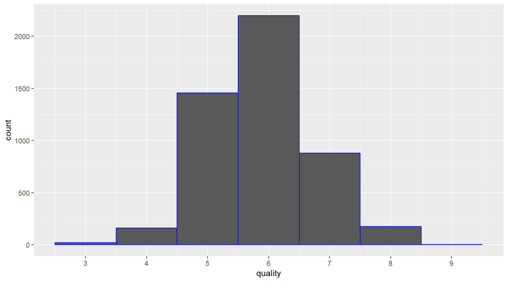

above indicates that a very few numbers of wine were rated 8 and 9. Most of our wine quality was between 5 and 6 as shown.

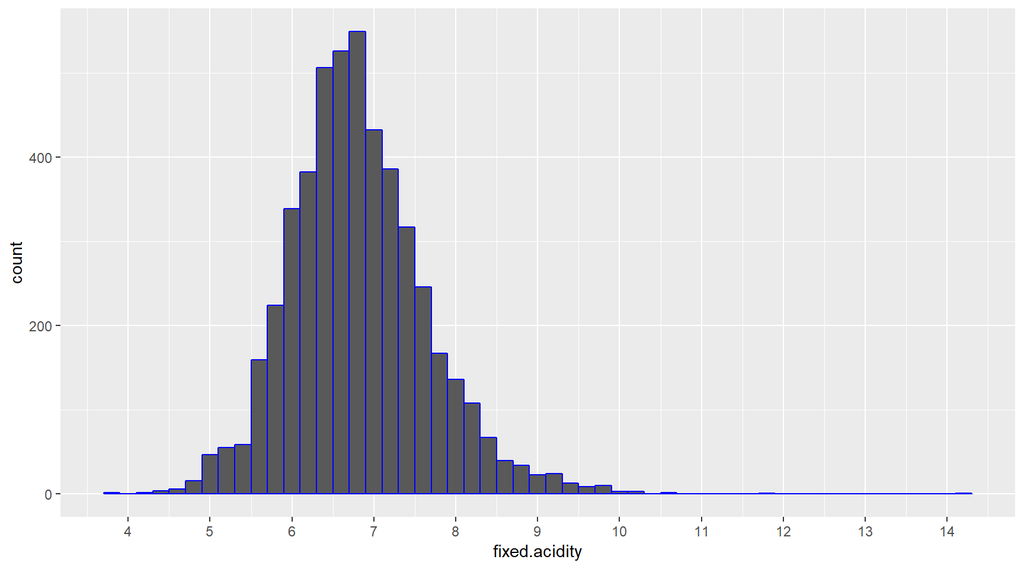

Fixed acidity mean is between 6 and 7, the graph is right skewed as shown. Fixed Acidity values are ranging between 3.8 and 14.2.

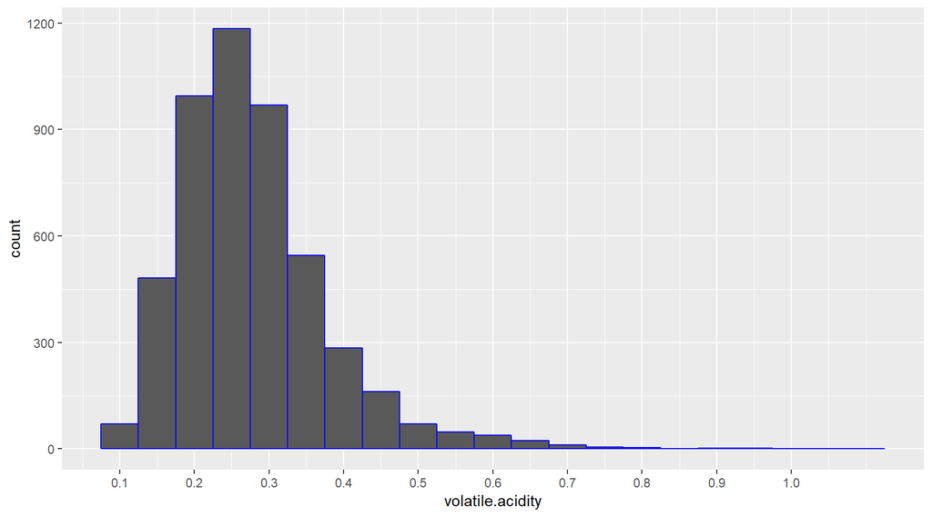

of Volitile acidity is right skewed as well, where the minimum is 0.08 and the maximum is 1.1

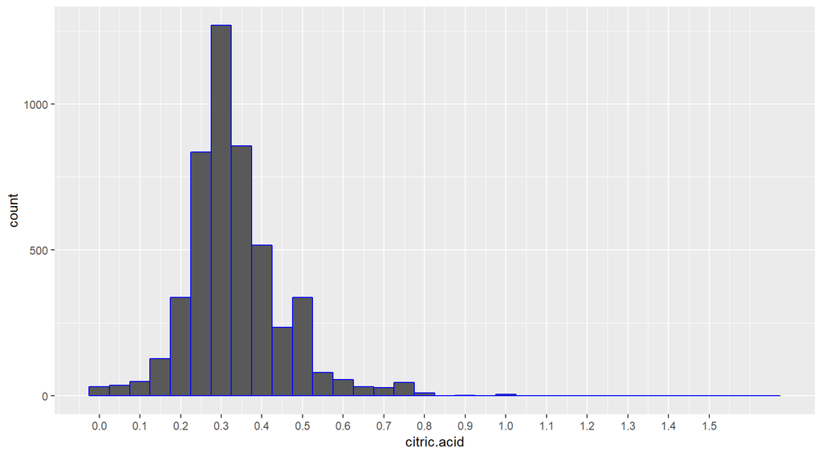

Citric Acid histogram is also right skewed with most values around 0.3. Citric Acid has a minimum of zero and maximum of 1.66.

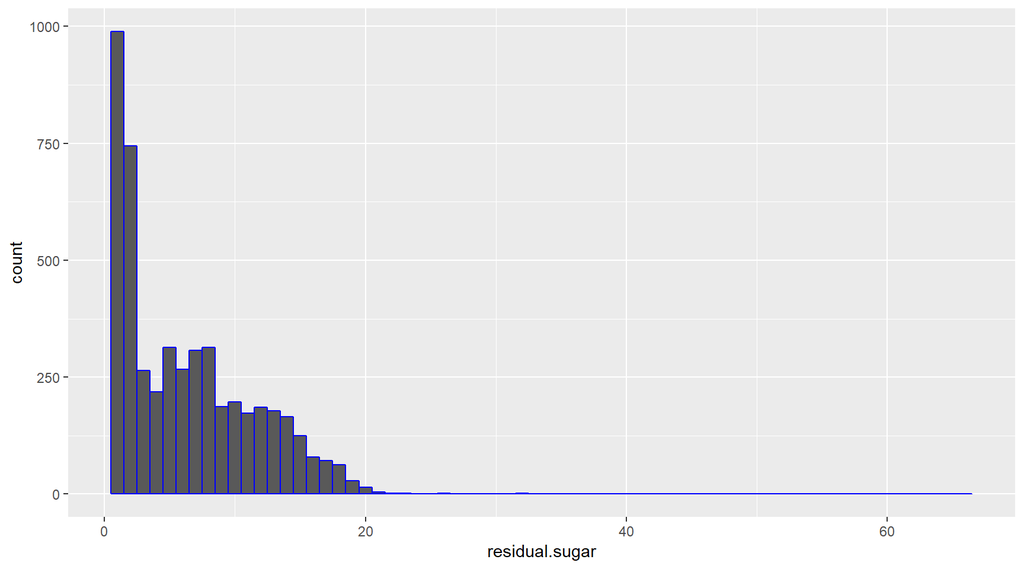

Right skewed graph for residual sugar histogram with most values around 1. Most of the residual sugar values are between 0 and 20, some outliers has high values that reach up to 60.

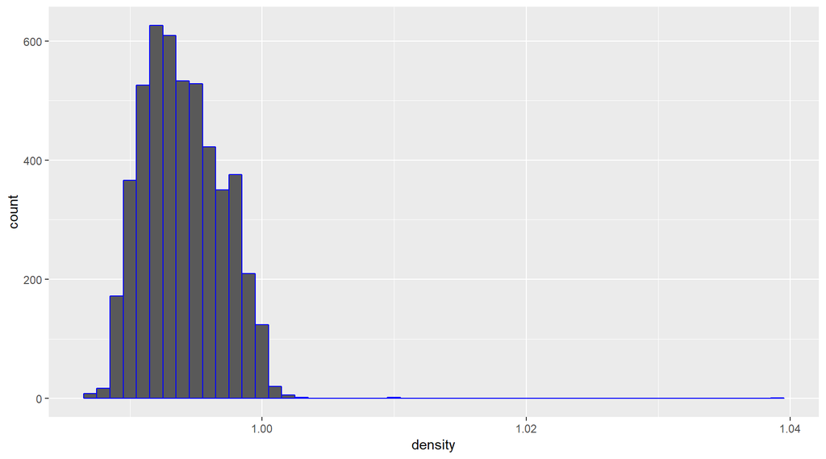

Density histogram looks more like bell shaped with 2 outliers.

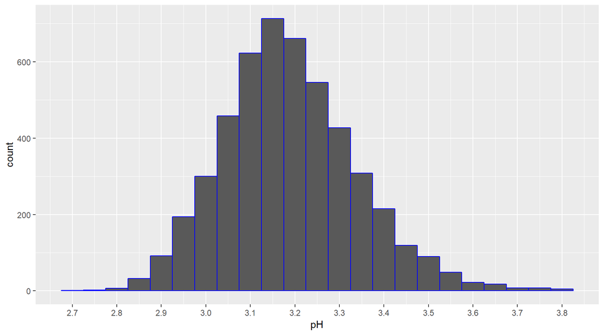

pH histogram is bell shaped with most of the values around 3.2. Values in pH range from 2.7 till 3.8.

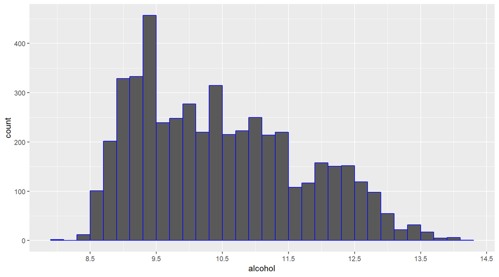

histogram shows that a big percentage of the dataset alcohol level is arround 9%, the higher the alcohol percentage, the lower the quantity of samples. Alcohol range is from 8% to 14.2%

# Univariate Analysis

### What is the structure of your dataset?

This dataset contains 4898 observations, each one has 12 columns(fixed.acidity, volatile.acidity, citric.acid, residual.sugar, chlorides, free.sulfur.dioxide, total.sulfur.dioxide, density, pH, sulphates, alcohol, quality)

### What other features in the dataset do you think will help support your investigation into your feature(s) of interest?

The date of creation of the wine would help for better investigation.

### Of the features you investigated, were there any unusual distributions? Did you perform any operations on the data to tidy, adjust, or change the form of the data? If so, why did you do this?

I removed the X column as it has no use.

# Bivariate Plots Section

```
##  [1] "fixed.acidity"        "volatile.acidity"     "citric.acid"
##  [4] "residual.sugar"       "chlorides"            "free.sulfur.dioxide"
##  [7] "total.sulfur.dioxide" "density"              "pH"
## [10] "sulphates"            "alcohol"              "quality"
```

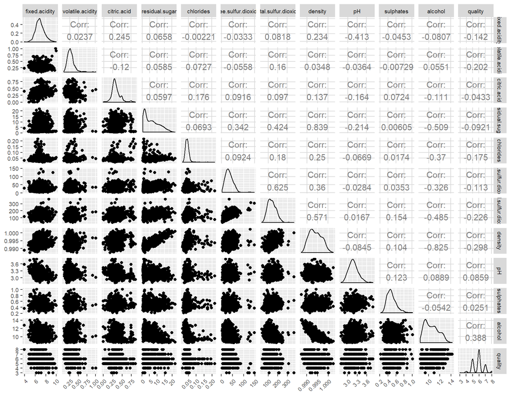

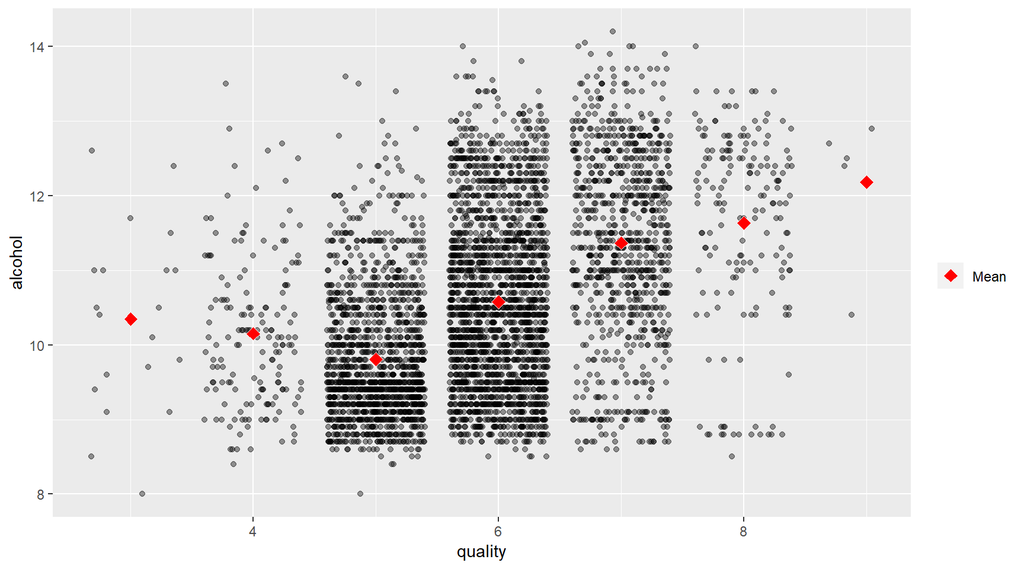

we can see starting from the rate 5 quality that the higher the alcohol level the better the quality. Graph shows that rate 5 and 6 has most of the dataset.

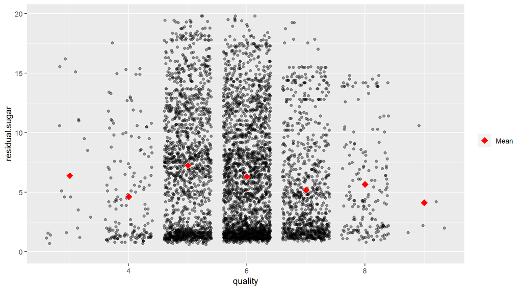

lower the residual sugar, the better the quality. As the graph is showing, the lower part of the graph has most of the dataset observations.

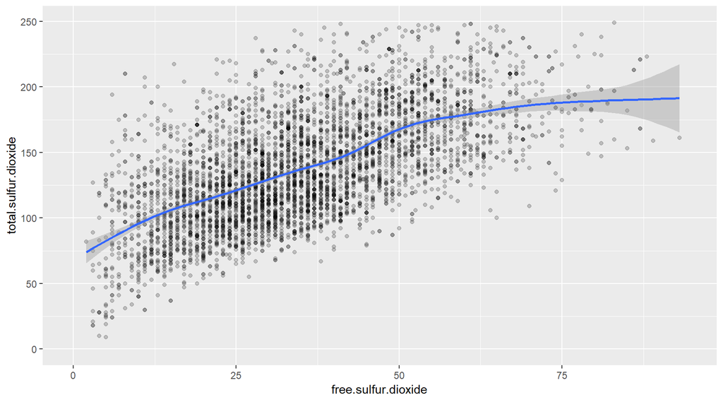

shows a positive relation between total and free sulfur dioxide.

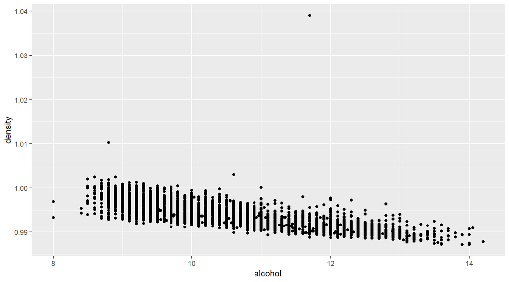

relation between density and alcohol levels in the above graph. The graph shows the higher the alcohol level, the lower the density.

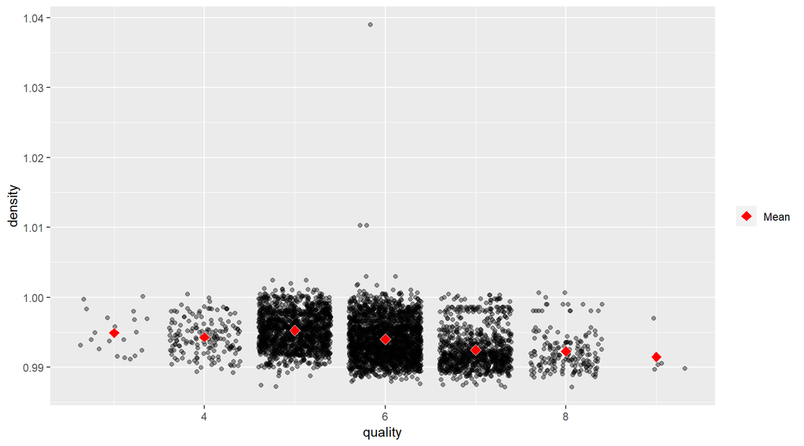

graph above is showing, that the lower the density the better the quality, we can link this conclusion to the the graph before it as well, and we can conclude that higher alcohol level leads to lower density levels, which leads to better quality.

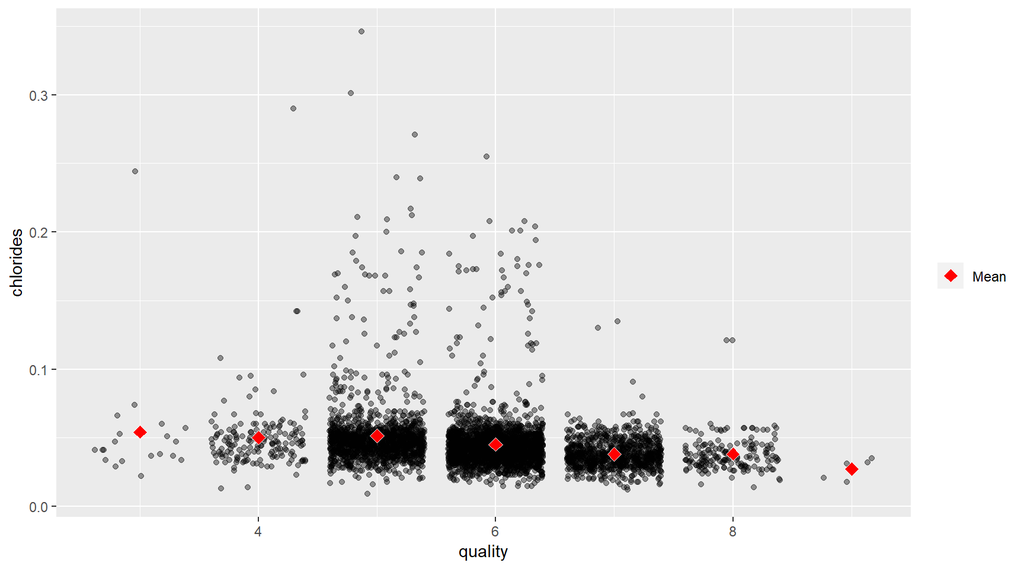

have a negative effect on the quality, the lower the better.

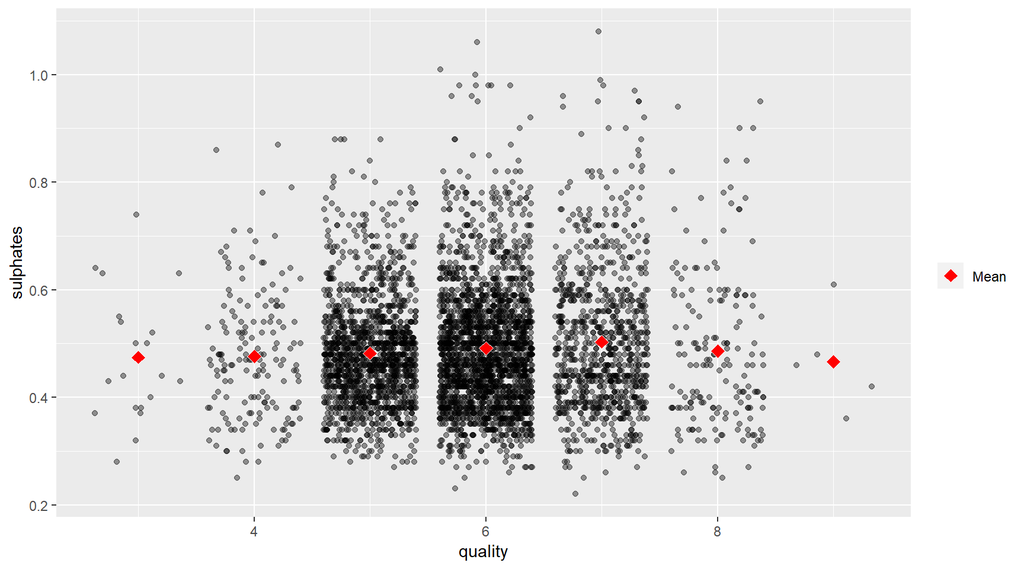

effect is minimal on the quality of the wine as shown, as its mean on all the quality values had a very small difference.

# Bivariate Analysis

### Did you observe any interesting relationships between the other features (not the main feature(s) of interest)?

A moderate correlation between free sulfur dioxide and total sulfur dioxide.

### What was the strongest relationship you found?

I have found a strong relation between density, residual sugar and alcohol

# Multivariate Plots Section

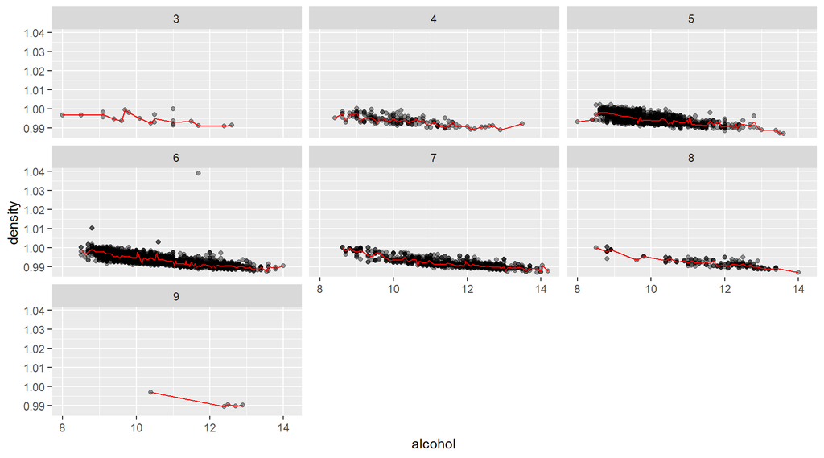

is a negative relation between alcohol precentage and density as we can see, higher alcohol levels have lower density.

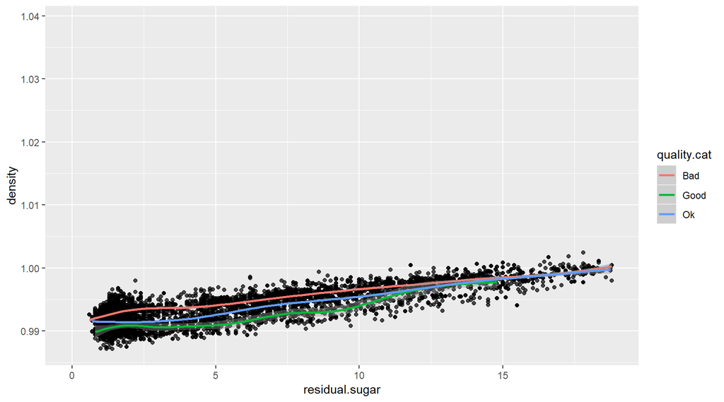

have better quality you need to have lower density and residual sugar

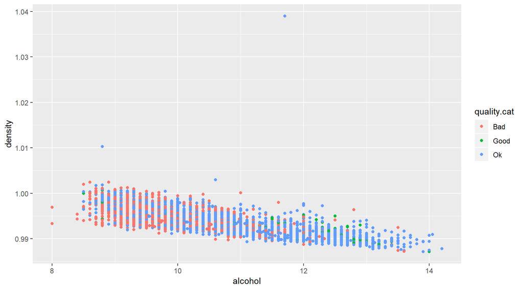

graph shows that the higher the alcohol and lower the density, the better the quality

# Multivariate Analysis

### Talk about some of the relationships you observed in this part of the investigation. Were there features that strengthened each other in terms of looking at your feature(s) of interest?

Graph cleared that quality is connected to lower density and lower residual sugar.

### Were there any interesting or surprising interactions between features?

## Most of the bad quality wine were between 8% and 10% alcohol

# Final Plots and Summary

### Plot One

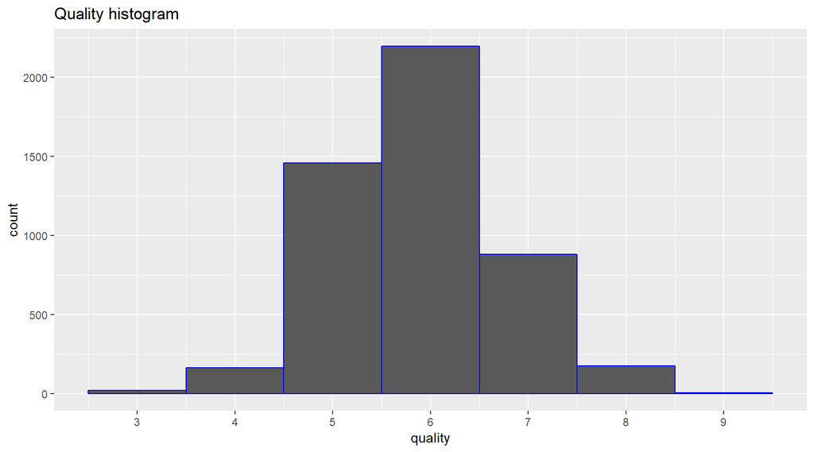

### Description One

In plot one, we can see that most of our quality observations are between 5 and 6, while a very small number of samples made it to 8 and 9. No sample took 10 as a rating in this dataset.

### Plot Two

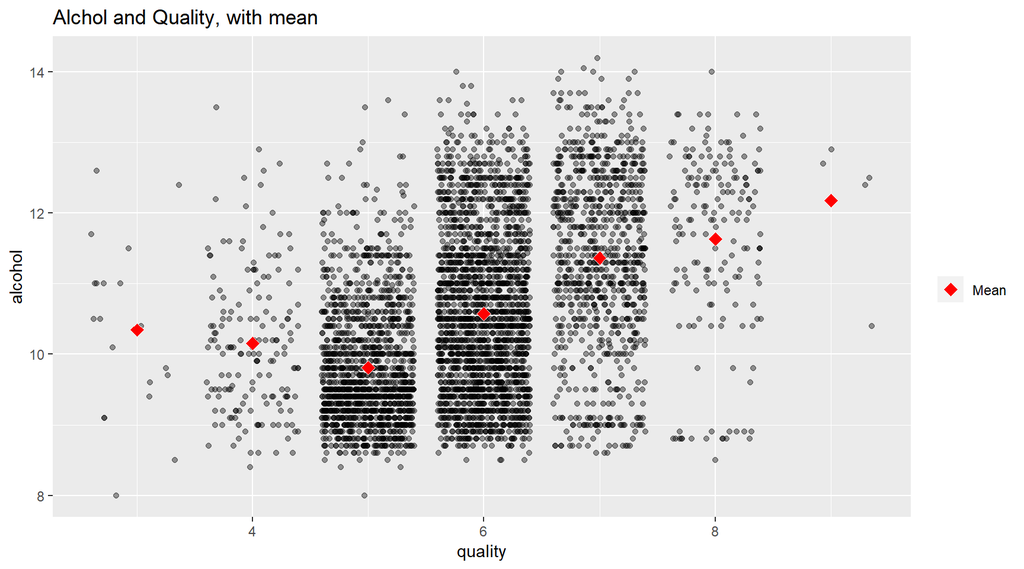

### Plot Three

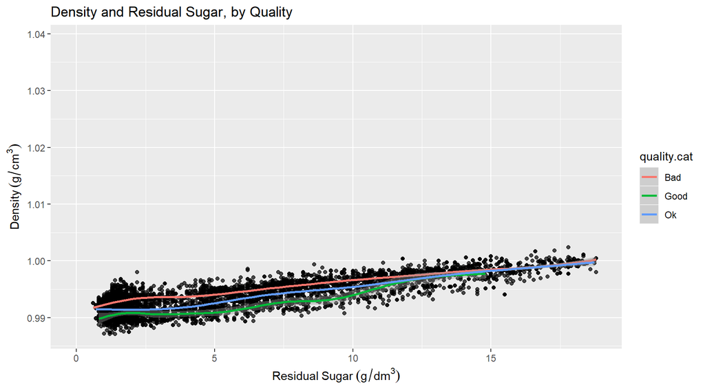

# Reflection

regarding strugles, I downloaded first the presidential funds received and found that this file after extraction is 250 MBs in a single csv file. I tried working with it but the ammount it takes to load was frustraiting, not sure if its because the file size or that it actually needs a higher computer to deal with.

In this dataset,it happened while using the quality variable while using facet_wrap as it didnt give the desired output to analyze it. Creating catogirical variable for quality eased in using it in multivariate analysis.

The project itself was not difficult, and I loved exploring new graphs in it. Its not hard to search for R functions on google or libraries, which I think its main strength.

I would love to do more projects and explorations for R and find an advanced course to sharpen my skills if possible.

For future analysis, I would like to compare the current variables to the variables in red wine dataset and check if it has the same outlines we defined here for better quality or it will differ in the red wine dataset.